# LLM-ek programozott használata kutatási célra

Tamási Árpád · ELTE TáTK

3. óra — 2026. szeptember 21.

# Vibe coding vs agentic engineering

## Vibe coding

**Andrej Karpathy** · 2025. február · a bejegyzés, amely elnevezte

> There’s a new kind of coding I call “vibe coding”, where you fully give in to the vibes, embrace exponentials, and forget that the code even exists.

> I “Accept All” always, I don’t read the diffs anymore.

> It’s not too bad for throwaway weekend projects.

## Agentic engineering

**Andrej Karpathy** · Sequoia AI Ascent · 2026. április 30.

> Vibe coding raises the floor. Agentic engineering is about extrapolating the ceiling.

> Agentic engineering is about preserving the quality bar of professional software. You are still responsible for your software, just as before.

## Mi a különbség

#### Vibe coding

- Azt nézed, **mit csinál**
- A prompt az egész terv
- A hibaüzenet megy vissza a gépbe
- Kész, ha működni látszik

#### Agentic engineering

- Azt is nézed, **hogyan csinálja**
- Specifikáció, aztán terv, aztán kis lépések
- Egy mérés mondja meg, mi a baj
- Kész, ha **meg tudod mutatni**

# A README hiányos

## A README-d jó — de nem specifikáció

Mindenki megírta, **mit akar**, és miért érdemes.

Azt nem, **mit jelent pontosan**, hogy kész van — annyira pontosan, hogy más is meg tudja csinálni.

A gép minden rést kitölt. És nem szól, hogy kitöltötte.

## Három példa arra, amit a README nem mond meg

| A README-ben | Jelentheti | Vagy jelentheti |
| --- | --- | --- |
| „a Budapesten élők **23%-a**” | a válaszolók közül | a „nem tudja” nélkül: **28,8%** |
| „**barátra** gondolt: igen/nem” | a szaktárs barát | a szaktárs nem barát |
| „a **legnagyobb területet** teszi ki” | négyzetkilométerben | lakóban, címben |

A gép választ egyet, és megy tovább.

## Követelmény

Minden rést megkeresünk, és egy **követelménnyel** töltjük ki:

```markdown
### Requirement: Megoszlás az érvényes válaszok között
Az ábrának az arányt a „nem tudja" válaszok
nélkül KELL számolnia, súlyozva.

#### Scenario: Van „nem tudja" válasz
- **WHEN** 200 válaszolóból 40 „nem tudja", 46 „hetente"
- **THEN** a „hetente" aránya `28,8%`, nem `23,0%`
```

# OpenSpec

## Egy eszköz, ami visszakérdez

[figure not shown]

- A réseket **kérdezve** keresi meg
- Nem kérdez meg mindent — de a kérdései **eszedbe juttatnak** továbbiakat. Mondd ki őket
- A válaszaidat követelményként írja le
- Időbe telik. Vidd végig.

## A parancsok

[figure not shown]

Ritkán kell beírni. A gép magától nyúl hozzájuk, amikor a beszélgetés odaér.

## explore — mire való

**Gondolkodás, mielőtt eldöntöd, mit csinálsz.**

- Amikor még nem tudod pontosan, mit akarsz
- Olvas, összevet, kérdez — nincs kötött menete
- **Kódot soha nem ír.** Tervet is csak akkor, ha igent mondasz

**A projektedben:** elolvassa a README-t, és megkérdezi, ami nem világos.

Ha összeállt a kép, felajánlja a javaslatot. Te annyit mondasz: *mehet.*

## Élő demó

[figure not shown]

Sziklaugró Acapulcóban

## A döntési pontok, 13 perc alatt

#### Mit tud

- **Mindhárom** képesség az első változatban
- A Word-űrlapot **is kitölti**
- **Ellenséges bíráló**, aki nem látta a beszélgetést
- „Mehet” **csak ellenőrzés után**
- **A kutató a felelős,** az eszköz figyelmeztet

#### A kar dokumentumai

- **A csomagban**, a verzió követi őket
- **Magyar és angol** beadvány
- **Bármelyik** nyelvű űrlap változik: új verzió
- Ha még nincs új verzió: **szól**

Egyik sem volt a README-ben.

## Sokat fog kérdezni

A gyors válasz csábító. De azt is lehet:

- **visszakérdezni** — miért számít, te mit választanál?
- **megnézetni vele az adatot** — és hogy melyik módszer illik hozzá
- **utánanézetni** — a definíciónak, a szabálynak, a forrásnak
- **ábrát kérni** — a folyamatról, egy eloszlásról, egy sornyi kimenetről
- és még: újraszámolni a példádat, mintát kérni, költséget becsülni…

Beszélgetés, nem űrlap.

## Kérdezz vissza

```
> Miért számít ez? Te mit választanál, és miért?
```

Bármelyik kérdésénél.

Megkapod az indokait — és megmondja, melyik rész a te döntésed.

## Nézd meg az adatomat

```
> Mielőtt bármit eldöntünk: nézd meg az adatot.
  Csak az oszlopneveket és a kitöltöttséget — a válaszokat ne.
```

| oszlop | kitöltve | amit észrevett |
| --- | --- | --- |
| `bizalom_kire` (szöveg) | 61% | a hiányzók fele **nem ezt hagyta ki**, hanem kilépett |
| `kor` | 98% |  |
| `iskolai_vegzettseg` | 97% |  |

Kitalált példa — így néz ki a válasz, ha csak a szerkezetet látja.

## Melyik módszer illik hozzá?

```
> Melyik mérőszámmal vessem össze a gépi és a kézi kódolást — és miért?
```

|  | gép: igen | gép: nem |
| --- | --- | --- |
| **te: igen** | 40 | 5 |
| **te: nem** | 7 | 48 |

**88%** egyezés — de a véletlen is hozna **50%**-ot. Cohen-féle **κ = 0,76**.

Kitalált számok, valódi számolás.

## Nézz utána a forrásnak

```
> Nézz utána a hivatalos szabálynak, mielőtt leírjuk. Mondd meg, hol találtad.
```

> „Ideális esetben ahhoz az irányítószámhoz kéne sorolni, ami az adott OEVK-n belül a **legnagyobb területet** teszi ki.”

Egy README-ből, szó szerint.

Különben fejből tölti ki — és ugyanolyan magabiztosan.

## Számold újra a saját példámat

```
> Számold újra a README-m példáját a saját szabályaim szerint. Kijön?
```

> „…látható legyen, hogy a Budapesten élők **23%-a** tartozik az egyik kategóriába…”

## Megvalósítható egyáltalán?

```
> Nézd meg a forrást: mit ad, hol a korlátja, és mi kell a hozzáféréshez?
```

> „Ezek most 2014-től vannak fent… De a korábbiakat is össze kell szednem.”

## Mekkora kézi minta kell?

```
> Mekkora kézi mintán tudnám megmondani, hogy a gép jól kódol?
```

## Csinálj felületet a kézi körhöz

```
> Csinálj egy felületet, amin végigkattintom a kézi kódolást —
> és ne lássam, mit mondott a gép.
```

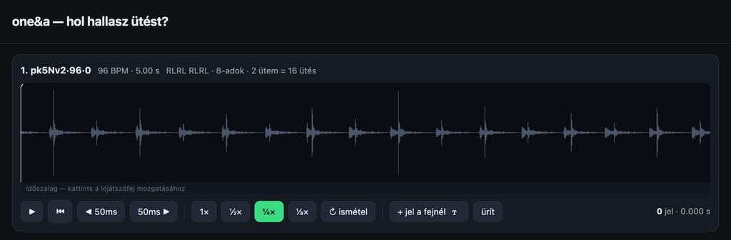

## Csinálj mintát, amit megmutathatok

```
> Készíts kitalált mintát ugyanazokkal a mezőkkel, mint az igazi adatom.
```

| Surname | First name | Year of birth | Actually present |
| --- | --- | --- | --- |
| Kertész | Mária | 1924 | 1 |
| Halmi | Ernő | 1931 | 0 |
| Szabados | Lili | 1928 | 1 |

A mezők valódiak, a sorok kitaláltak. Ez mehet a repóba.

## Mennyibe kerül?

```
> Hány AI-hívás egy futás a teljes anyagon, és mennyi pénz?
```

| A README-ből | Hívás | Nagyságrend |
| --- | --- | --- |
| 48 kísérleti cella × 50 ismétlés | 2 400 | **< 1 $** |
| néhány száz szöveges válasz | ~500 | **~1 $** |
| tízezer szkennelt oldal | ~10 000 | **~45 $** |

A szöveg olcsó. A kép drága.

## Rajzold le a folyamatot

```
  kesz beadvany (keab/)
         |
         v
  +---------------------------+     nem latta a beszelgetest,
  |  "BIRALO"                 |     csak a papirt es a szabalyzatot
  +---------------------------+
         |   keresi, mibol lenne hianypotlas:
         |    - ellentmondas a 7.2 es a 7.4 kozott
         |    - hianyzo melleklet, rossz kutatasvezeto
         v
  kifogaslista ---> kutato javit ---> ujra biralat
```

Valódi ábra a keab explore-jából — kérés nélkül rajzolta.

## Segíts kitalálni, mi legyen az anyag

> „Igazából ezt nem tudom…” · „Nos, ezt nem tudom.” · „Minden hiányzik.”

Három README-ből, szó szerint.

```
> Még nem tudom, mit elemezzek. Javasolj három lehetséges mintát,
  és mondd meg, melyikkel mit tudnék megmérni.
```

A „nem tudom” jó kiindulópont.

## Kell hozzá etikai engedély?

```
> Mi számít ebben a projektben személyes adatnak, és kell-e hozzá engedély?
```

Ezt most kérdezd — nem amikor már gyűjtöd az adatot.

# Amikor kész

## Innen magától jön

| Lépés | Mi történik |
| --- | --- |
| `propose` | **meg fogja kérdezni**, megírja-e a javaslatot |
| `apply` | **fel fogja ajánlani** |
| `archive` | ezt is **fel fogja ajánlani** |

Minden szakasz után, így, az agentnek:

```
git commit push
```

## apply — megépíti

**Pontosan azt, amit a terv mond, lépésenként.**

- Végigmegy a `tasks.md`-n, és kipipálja
- Ha kiderül, hogy a terv rossz: **a tervet javítod**, nem csak a kódot

**A projektedben:** az első mérés kódja, a specifikációd ellen — és az első futás.

Ami marad: a kód, és hogy melyik lépés írta.

## archive — a hatályos szövegbe

Mint egy törvénymódosítás: amíg vitatják, külön dokumentum. Elfogadás után beíródik az egységes szerkezetbe, a módosító javaslat pedig irattárba kerül.

- Előtte: `openspec/changes/<név>/`
- Utána: `openspec/specs/` — amit a projekt **most** csinál
- A javaslat megmarad, dátummal: `changes/archive/`

A következő javaslat már ehhez a szöveghez képest készül.

# A házi

## Először: napló és „nem vagyok fejlesztő”

A projekted **`AGENTS.md`**-jének elejére:

```markdown
Nem vagyok fejlesztő. A technikai részt intézd te,
nekem azt mondd el, amit nekem kell eldöntenem.

## Döntési napló
Ha bármit eldöntünk a projektről — követelményt, számot,
nevet, eszközt —, írj egy sort a dontesek.md végére:
dátum, mit döntöttünk, és hogy én döntöttem vagy te.
Korábbi sort soha ne írj át.
```

A **`CLAUDE.md`**-be egy sor: `@AGENTS.md`

## Az OpenSpec telepítése

Ugyanúgy, mint a múlt héten: **kérd meg rá.**

```
Telepítsd nekem az OpenSpec 1.13.0-s verzióját, és futtasd
le az openspec init-et ebben a repóban. Ha nincs Node,
előbb azt tedd fel. Utána mondd el, mit változtattál.
```

A projekted mappájában — ne a gyűjtőmappában.

## Amit az init hagy maga után

```
openspec/
  config.yaml   ← beállítások; hagyd, ahogy van
  specs/        ← a hatályos szöveg: mit csinál a projekt
  changes/      ← folyamatban lévő javaslatok

.claude/skills/openspec-*   ← a parancsok
```

## Jövő hétre

1. **`AGENTS.md`** — a „nem vagyok fejlesztő” és a döntési napló
2. **OpenSpec** — a gép telepíti, `init`
3. **explore** — menj végig a kérdésein
4. **apply** és **archive** — egy teljes kör
5. **Commit, push**

Tedd fel, amid van: péntek reggel · Kész: vasárnap 20:00

Elakadás esetén: **Issue a saját projekted repójában.**

## Jó szórakozást

Amikor legközelebb találkozunk, már fut a cuccotok.